# R Notebook

Aaron J. Wilk

Integrative analysis of peripheral immune dynamics in SARS-CoV-2 infection Please see our publication at: https://www.nature.com/articles/s41591-020-0944-y

This notebook will enable generation of the Seurat object used for post-processing from count matrices deposited on GEO. For code on downstream analysis and figure reproduction, please see the notebook “covid_analysis_markdown.Rmd”

Load libraries # NOTE: Please be sure to run the script “additionalFunctions_repo.R” to read homemade functions into the global environment

```r
library(EpicTools)
```

[output not shown]

# LOADING DATA

Download built count matrices from GEO (https://www.ncbi.nlm.nih.gov/geo/query/acc.cgi?acc=GSE150728) and save them in the same directory.

Additionally, download the count matrix for patient 560 (AKA C6) from the github repository (https://github.com/ajwilk/2020_Wilk_COVID/blob/master/data/count_matrices/560_cell.counts.matrices.rds?raw=true). This patient did not consent to the sharing of sequence-level data and thus we are only able to share processed data and there is no GEO entry.

```r
names(cm.files) <- sub(path,"",
                       sub("\\_cell.counts.matrices.rds", "", cm.list))
```

[output not shown]

pre-processing

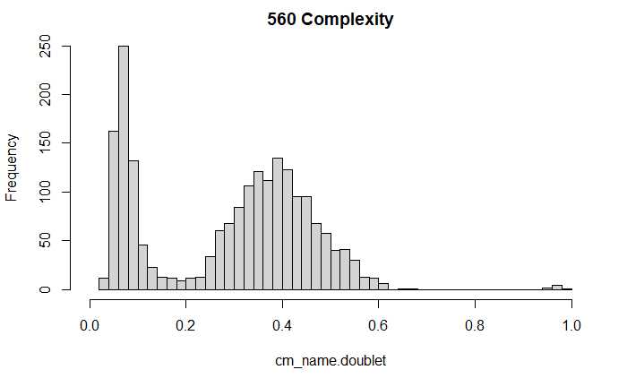

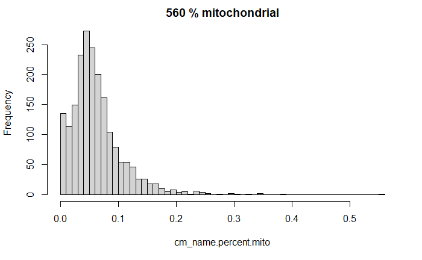

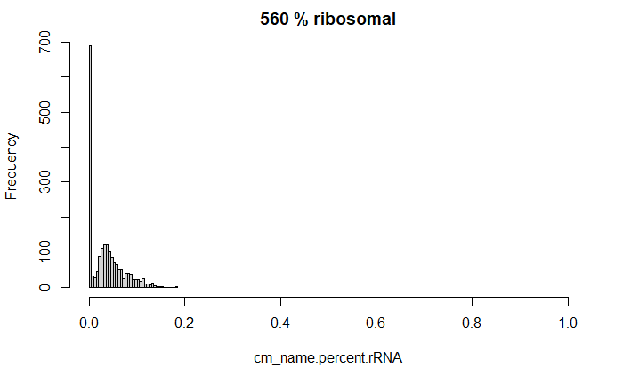

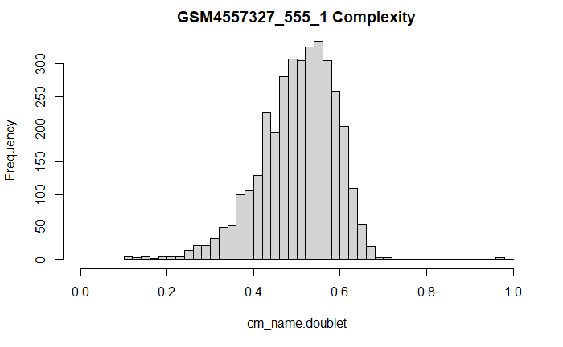

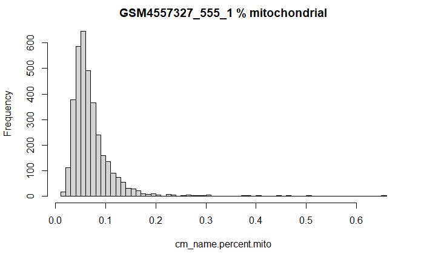

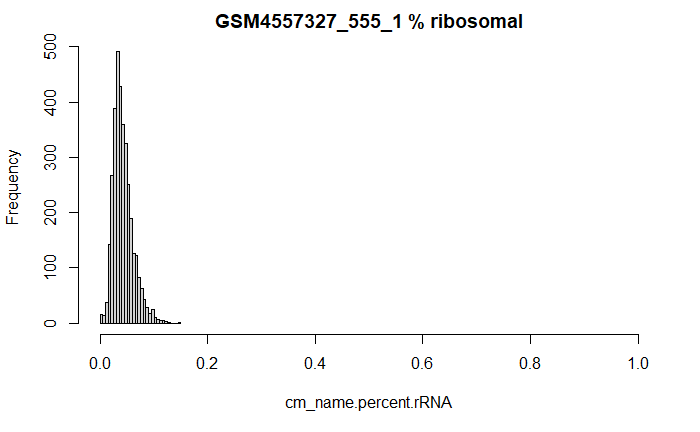

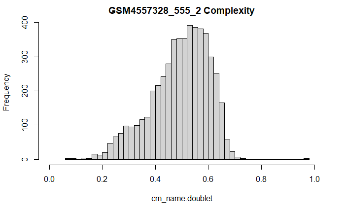

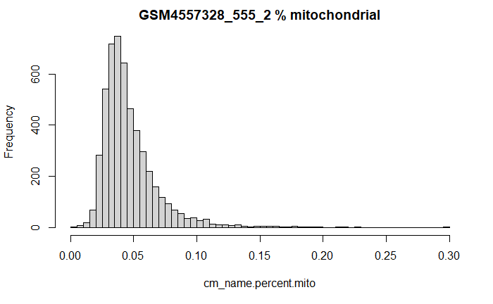

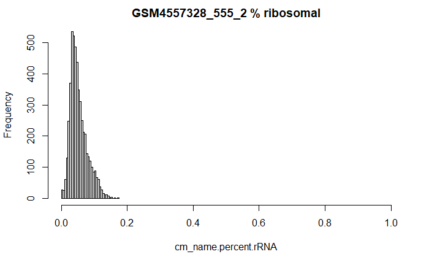

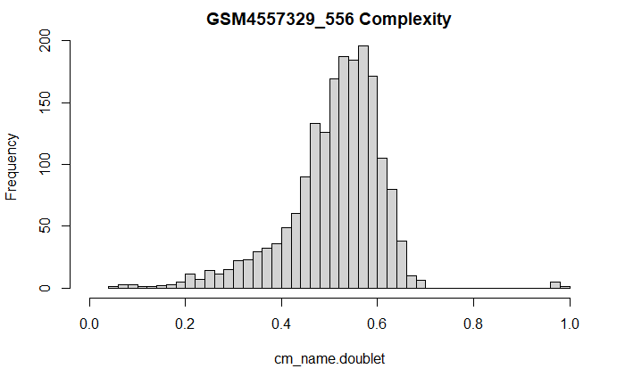

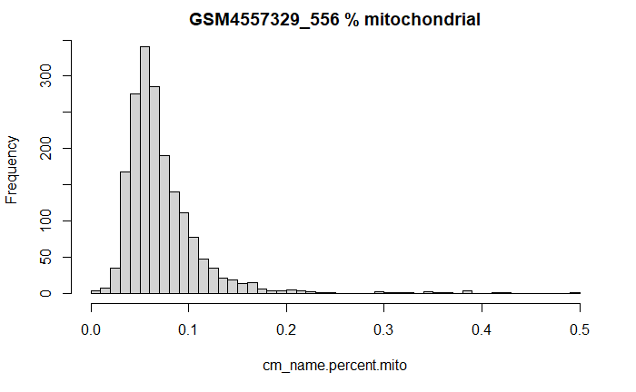

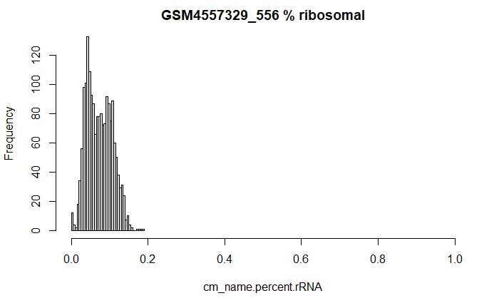

[30 more figures not shown]

Merge

```r
covid_combined.emat <- mergeCM(cm.pp, type = "emat")
```

[output not shown]

Make Seurat object

```r
covid_combined <- RunPCA(covid_combined, verbose = FALSE)
```

[output not shown]

Add metadata

```r
covid_metadata <- read_csv("https://raw.githubusercontent.com/ajwilk/2020_Wilk_COVID/master/code/COVID-19_metadata_repo.csv")
#NOTE: ensure that rownames of covid_metadata match orig.ident fields in object. This is impacted by the naming of the count matrices submitted to GEO
seurat_metadata <- covid_combined@meta.data
seurat_metadata <- seurat_metadata[,!(colnames(seurat_metadata)) %in%
                                     setdiff(colnames(covid_metadata), "orig.ident")]
metadata_combined <- merge(seurat_metadata, covid_metadata, by = "orig.ident")
rownames(metadata_combined) <- rownames(covid_combined@meta.data)

covid_combined@meta.data <- metadata_combined
```

```r
sars.names <- c("MN994467.1", "MN994468.1", "MT027062.1", "MT027063.1", "MT027064.1", "MT044258.1", "MT106052.1", "MT106053.1", "MT118835.1", "MT192765.1")
covid.pos <- covid_combined.emat[grep(paste(sars.names,collapse="|"), rownames(covid_combined.emat)),]
covid.pos.cells <- names(covid.pos[covid.pos !=0])
length(covid.pos.cells) #no SARS-CoV-2 reads detected in dataset
```

```r
covid_combined.markers <- FindAllMarkers(covid_combined, only.pos = TRUE, min.pct = 0.25, logfc.threshold = 0.25)
covid_combined.markers %>% group_by(cluster) %>% top_n(n = 10, wt = avg_logFC)
```

Cluster 3 is a low quality cluster. Are there any genes other than poor quality genes that are upregulated in it?

```r
crap.markers <- FindMarkers(covid_combined, ident.1 = "3")
crap.markers[order(-crap.markers$avg_logFC),]
```

Will remove. Same with cluster 12

```r
crap2.markers <- FindMarkers(covid_combined, ident.1 = "12")
crap2.markers[order(-crap2.markers$avg_logFC),]
```

Will also remove cluster 12

SingleR annotation

```r
ref <- HumanPrimaryCellAtlasData()
common <- intersect(rownames(ref), rownames(covid_combined.emat))
combined.emat.singler <- covid_combined.emat[common,]
ref <- ref[common,]
combined.emat.singler.sce <- SingleCellExperiment(assays = list(counts = combined.emat.singler))
combined.emat.singler.sce <- logNormCounts(combined.emat.singler.sce)
```

```r
singler.pred <- SingleR(test = combined.emat.singler.sce@assays@data@listData$logcounts, ref = ref, labels = ref$label.main)
table(singler.pred$labels)
```

```r
plotScoreHeatmap(singler.pred, clusters = covid_combined@meta.data$orig.ident)
plotScoreHeatmap(singler.pred, clusters = covid_combined@meta.data$seurat_clusters)
```

```r
singler.results <- merge(data.frame(cell = rownames(singler.pred), singler = singler.pred$labels),
                         data.frame(cell = rownames(covid_combined@meta.data),
                                    cluster = covid_combined@meta.data$seurat_clusters),
                         by = "cell",
                         all.y = FALSE)
singler.results$cell <- NULL
singler.results$count <- 1
singler.results <- aggregate(count ~ ., singler.results, FUN = sum)
singler.final <- singler.results %>% group_by(cluster) %>% top_n(n = 1, wt = count)
singler.final
covid_combined$singler <- singler.pred$labels
DimPlot(covid_combined, group.by = "singler", label = T) + NoLegend()
```

Removing crap clusters, re-embedding and re-clustering

```r
covid_combined.nc <- subset(covid_combined, idents = setdiff(unique(covid_combined$seurat_clusters), c("3", "12")))
covid_combined.nc <- RunPCA(covid_combined.nc, verbose = FALSE)
covid_combined.nc <- RunUMAP(covid_combined.nc, dims = 1:50, verbose = FALSE)
covid_combined.nc <- FindNeighbors(covid_combined.nc, dims = 1:50, verbose = FALSE)
covid_combined.nc <- FindClusters(covid_combined.nc, resolution = 1, verbose = FALSE)
DimPlot(covid_combined.nc, label = TRUE) + NoLegend()
```

```r
singler.results <- merge(data.frame(cell = rownames(singler.pred), singler = singler.pred$labels),
                         data.frame(cell = rownames(covid_combined.nc@meta.data),
                                    cluster = covid_combined.nc@meta.data$seurat_clusters),
                         by = "cell",
                         all.y = FALSE)
singler.results$cell <- NULL
singler.results$count <- 1
singler.results <- aggregate(count ~ ., singler.results, FUN = sum)
singler.final <- singler.results %>% group_by(cluster) %>% top_n(n = 1, wt = count)
singler.final
```

Coarse annotations: 0: NK cell 1: T cell 2: T cell 3: Monocyte 4: T cell 5: B cell 6: Monocyte 7: Monocyte 8: Monocyte 9: B cell 10: Monocyte 11: NK cell 12: RBC 13: T cell 14: RBC 15: T cell 16: B cell 17: Platelet 18: B cell 19: T cell 20: Monocyte 21: B cell 22: T cell 23: B cell 24: CMP 25: Neutrophil 26: Monocyte 27: Myelocyte 28: Monocyte 29: B cell

```r
covid_combined.nc.markers <- FindAllMarkers(covid_combined.nc, only.pos = T)
covid_combined.nc.markers %>% group_by(cluster) %>% top_n(n = 10, wt = avg_logFC)
```

```r
DotPlot(Seurat:::subset.Seurat(covid_combined.nc,
                               idents = unlist(lapply(singler.final[singler.final$singler=="T_cells","cluster"],
                                                      as.character))),
        features = c("CD4", "PRF1", "GZMB", "GZMA", "CD8A", "RORC", "EOMES", "TBX21"))
DotPlot(Seurat:::subset.Seurat(covid_combined.nc,
                               idents = unlist(lapply(singler.final[singler.final$singler=="T_cells","cluster"],
                                                      as.character))),
        features = c("PTK7", "PECAM1", "ITGAE", "CD44", "CR2", "IL2RA", "FAS", "IL2RB"))
DotPlot(Seurat:::subset.Seurat(covid_combined.nc,
                               idents = unlist(lapply(singler.final[singler.final$singler=="T_cells","cluster"],
                                                      as.character))),
        features = c("SELL", "CCR7", "CD44", "CD28", "CD27", "IL7R", "CXCR3", "ITGAL", "CD58"))
DotPlot(Seurat:::subset.Seurat(covid_combined.nc,
                               idents = unlist(lapply(singler.final[singler.final$singler=="T_cells","cluster"],
                                                      as.character))),
        features = c("TRDC", "TRGC1", "TRGC2", "KLRB1", "KLRK1"))
```

```r
DotPlot(Seurat:::subset.Seurat(covid_combined.nc,
                               idents = unlist(lapply(singler.final[singler.final$singler=="Monocyte","cluster"],
                                                      as.character))),
        features = c("CD14", "LYZ", "FCGR3A", "IL1B", "IDO1", "FCER1A", "FLT3", "IL3RA", "NRP1"))
DotPlot(Seurat:::subset.Seurat(covid_combined.nc,
                               idents = unlist(lapply(singler.final[singler.final$singler=="B_cell","cluster"],
                                                      as.character))),
        features = c("MME", "CD22", "FCER2", "CD38", "CD44", "CD27", "SDC1"))
```

```r
DotPlot(Seurat:::subset.Seurat(covid_combined.nc, idents = c(covid_myeloid.idents)), features = unique(c("CD14", "LYZ", "FCGR3B", "FCGR3A", "CLC", "ELANE", "LTF", "MPO", "CTSG", "IDO1", "FCER1A", "FLT3", "IL3RA", "NRP1", "MME", "CD22", "FCER2", "CD44", "CD27", "SDC1", "CD4", "CD8A", "ITGAL", "SELL", "GZMB", "CD3E", "CD3G", "CD3D")), group.by = "cell.type.fine") + ggpubr::rotate_x_text()
ggsave("p.pdf", path = "~/Downloads/", height = 5, width = 10)
```

```r
covid_myeloid.idents <- c("3", "6", "7", "8", "10", "20", "24", "25", "26", "27", "28")
covid_B.idents <- c("5", "9", "16", "18", "21", "24", "27", "29")
covid_T.idents <- c("1", "2", "4", "13", "15", "19", "22")
covid_NK.idents <- c("0", "11")

covid_CD4T.idents <- c("2", "4", "19")
covid_CD8T.idents <- c("1", "13", "15")
covid_gdT.idents <- c("22")
covid_CD14mono.idents <- c("3", "6", "7", "8")
covid_CD16mono.idents <- c("10", "28")
covid_DC.idents <- c("20", "26")

covid_fine.idents <- c("NK", "CD8m T", "CD4m T", "CD14 Monocyte", "CD4n T", "B", "CD14 Monocyte", "CD14 Monocyte", "CD14 Monocyte", "IgM PB", "CD16 Monocyte", "NK", "RBC", "CD8eff T", "RBC", "CD8m T", "IgG PB", "Platelet", "IgG PB", "CD4 T", "DC", "IgA PB", "gd T", "IgA PB", "SC & Eosinophil", "Neutrophil", "pDC", "Developing Neutrophil", "CD16 Monocyte", "IgA PB")

covid_coarse.idents <- c("NK", "CD8 T", "CD4 T", "CD14 Monocyte", "CD4 T", "B", "CD14 Monocyte", "CD14 Monocyte", "CD14 Monocyte", "B", "CD16 Monocyte", "NK", "RBC", "CD8 T", "RBC", "CD8 T", "PB", "Platelet", "PB", "CD4 T", "DC", "PB", "gd T", "PB", "Granulocyte", "Granulocyte", "pDC", "Granulocyte", "CD16 Monocyte", "PB")
```

This Seurat object can now be used for post-processing analysis using the “covid_analysis_markdown.Rmd” notebook.